# Non-Linear Model Specifications

Based on these results, we expect from the experience of the log-log model that the relationship between **IncTFt** and the two explanatory variable associated with the household heads will be linearly described if only the long right tailed coefficient is logarithmized. However, we do not logarithmize education and age as explanatory variables because their distributions are not so long right tailed.  
Let’s plot this:

First, we analyze the connection of **HhEd** and **IncTFt**:

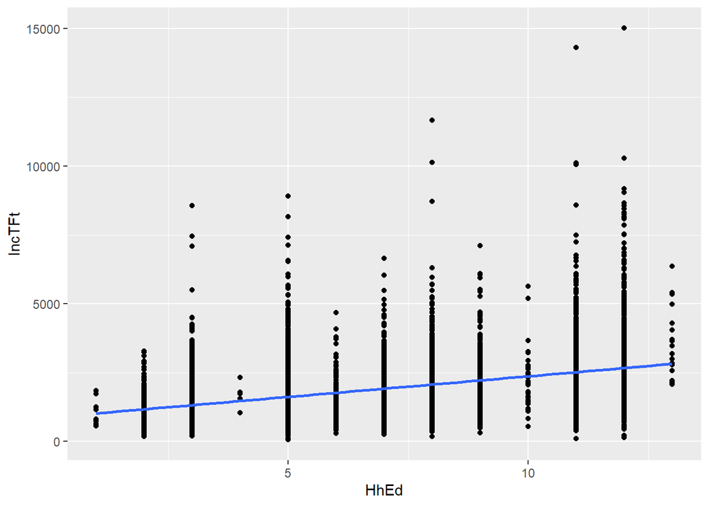

```r
#Connection of base variables on scatter plot
ggplot(hh_filtered, aes(x=HhEd, y=IncTFt)) +
  geom_point() + geom_smooth(method = lm)
```

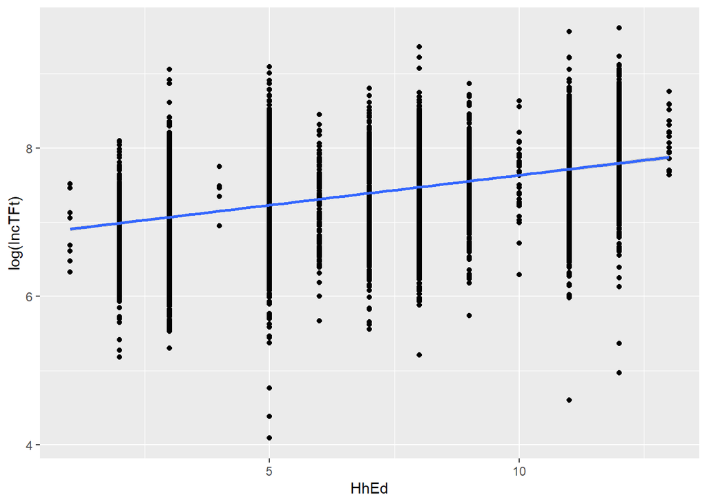

```r
#Connection of base variables on scatter plot
ggplot(hh_filtered, aes(x=HhEd, y=log(IncTFt))) +
  geom_point() + geom_smooth(method = lm)
```

Here we have about what we expected: by logarithmizing the outcome variable, a linear trend line better describes the relationship.

Let’s then also consider the relationship between **HhAge** and **IncTFt** on a dot plot:

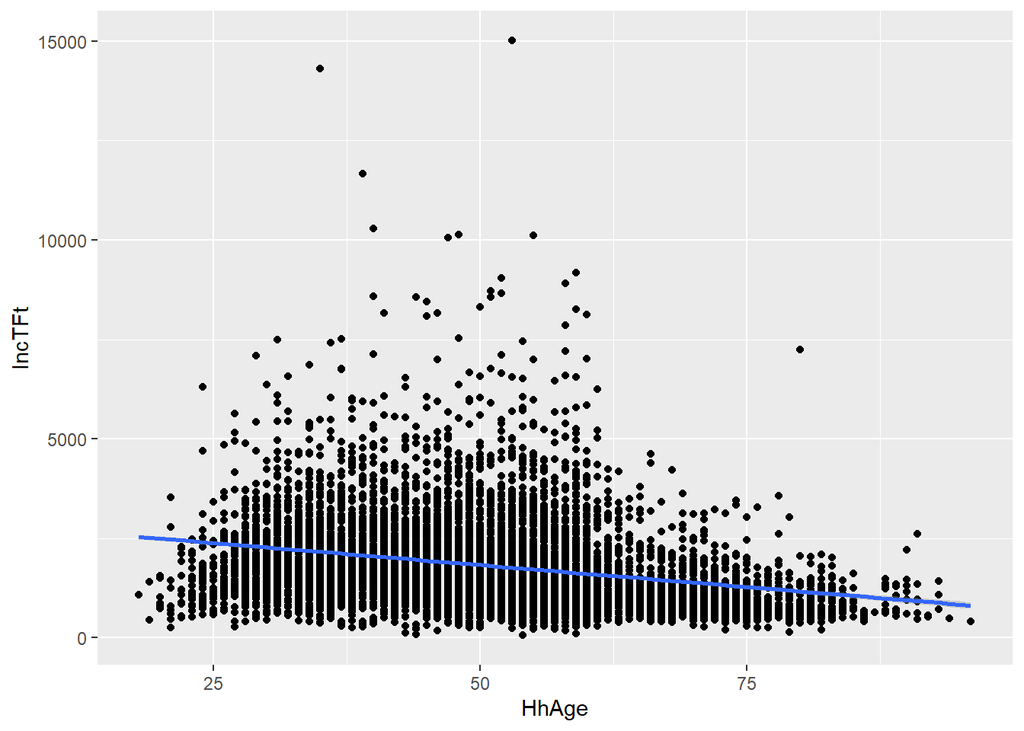

```r
#Connection of base variables on scatter plot
ggplot(hh_filtered, aes(x=HhAge, y=IncTFt)) +
  geom_point() + geom_smooth(method = lm)
```

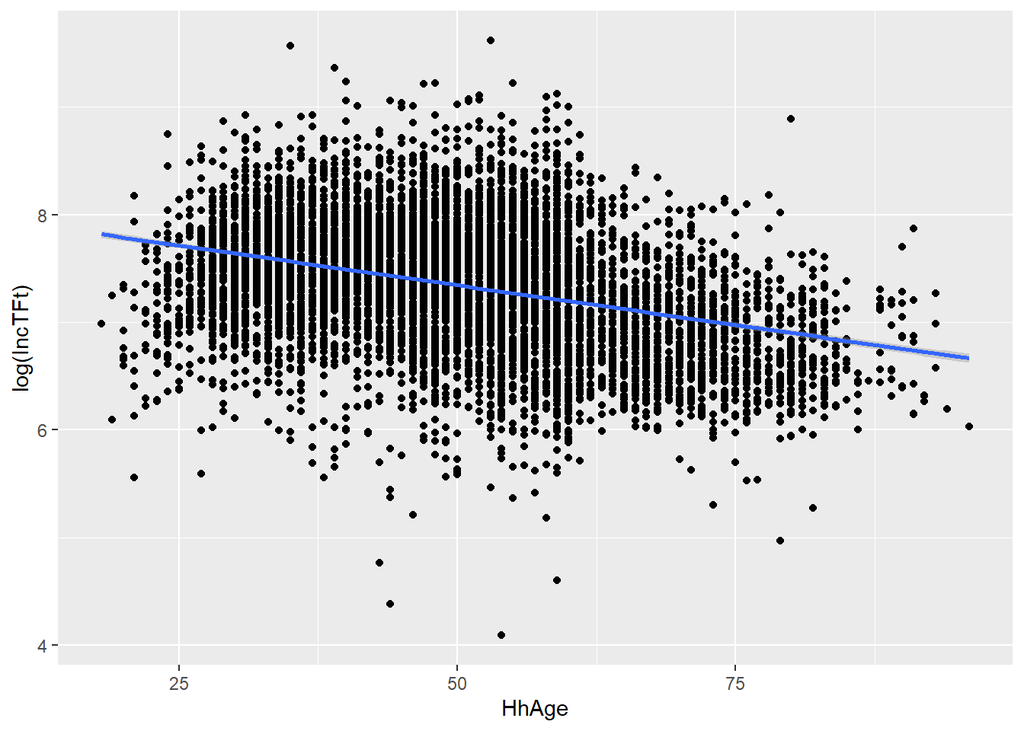

```r
#Connection of base variables on scatter plot
ggplot(hh_filtered, aes(x=HhAge, y=log(IncTFt))) +
  geom_point() + geom_smooth(method = lm)
```

Let’s then see the **log-lin** OLS model we have constructed to estimate income:

```r
loglin <- lm(log(IncTFt) ~ NrMems + HhEd + HhAge + I(HhAge^2), data=hh_filtered)
summary(loglin)
```

```
##
## Call:
## lm(formula = log(IncTFt) ~ NrMems + HhEd + HhAge + I(HhAge^2),
##     data = hh_filtered)
##
## Residuals:
##     Min      1Q  Median      3Q     Max
## -3.6346 -0.2549  0.0049  0.2627  2.0137
##
## Coefficients:
##               Estimate Std. Error t value Pr(>|t|)
## (Intercept)  6.036e+00  5.483e-02  110.09  < 2e-16 ***
## NrMems       2.313e-01  3.903e-03   59.26  < 2e-16 ***
## HhEd         7.402e-02  1.639e-03   45.16  < 2e-16 ***
## HhAge        1.057e-02  2.101e-03    5.03 5.01e-07 ***
## I(HhAge^2)  -1.226e-04  1.999e-05   -6.13 9.24e-10 ***
## ---
## Signif. codes:  0 '***' 0.001 '**' 0.01 '*' 0.05 '.' 0.1 ' ' 1
##
## Residual standard error: 0.4199 on 7564 degrees of freedom
## Multiple R-squared:  0.4972, Adjusted R-squared:  0.4969
## F-statistic:  1870 on 4 and 7564 DF,  p-value: < 2.2e-16
```

From to table of coefficients our equation looks like this:

$\ln{IncTFt}=6.036+0.23 \times NrMems+0.074 \times HhEd+0.0106 \times HhAge-0.000123 \times HhAge^2$

By raising this to the power of $e$, we also obtain the equation for the direct estimate of the income:

$IncTFt=e^{6.036+0.23 \times NrMems+0.074 \times HhEd+0.0106 \times HhAge-0.000123 \times HhAge^2}$

We can see that in this setup, $\beta$ must be interpreted by raising them to the power of $e$! Then the $e^{\beta}$’s become so-called growth factors. Let us examine the case of $\beta_{HhEd}$:

```r
# including the axis section the beta of HhEd is the 3rd coefficient
exp(loglin$coefficients[3])
```

```
##     HhEd
## 1.076831
```

All else being unchanged, if the education level of the head of household increases by one year, his or her income is expected to change by a factor of 1.077, or 7.7%.

The situation is a bit more complex for age, because there the marginal effect will also depend on the initial age due to the squared term. Let’s see to what the marginal effect of **HhAge** on **IncTFt** comes out. First, we partially derive the logarithmic equation and then raise the result to the power of $e$:

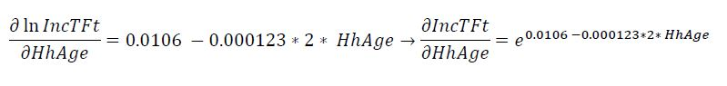

If we take a 40 year old head of household for example, this is the value we get:

```r
# including the axis section HhAge and its square are 4th and 5th
exp(loglin$coefficients[4]+loglin$coefficients[5]*2*40)
```

```
##    HhAge
## 1.000767
```

In other words, if the age of the head of household increases ceteris paribus by 1 year compared to 40, then income is expected to change by a factor of 1.0007, i.e. increase by 0.07%.

### 5.1. Mixed model

In this log-lin model, we could also include the value of the apartment (**HousePrice**). Logically, the household that lives in a more valuable apartment will presumably have a higher annual income.

Let us also see how the values of the apartments are distributed:

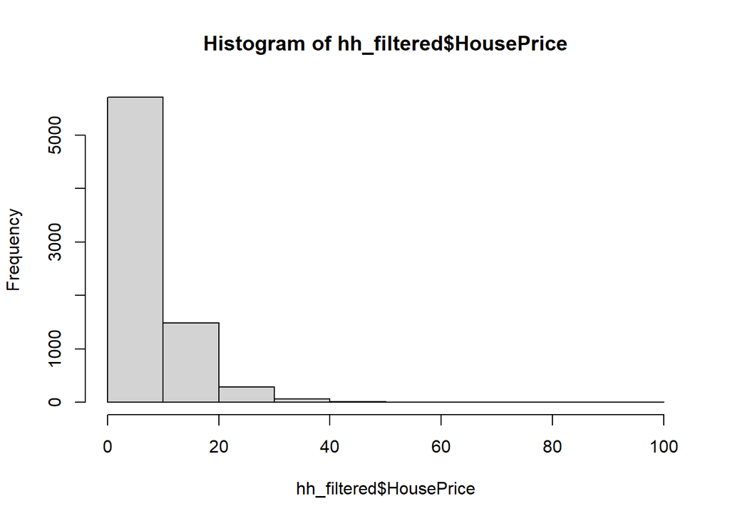

```r
hist(hh_filtered$HousePrice)
```

Unsurprisingly, it has a long right tail. :) So the relationship of the variable with the annual income becomes linear if you logarithmize both:

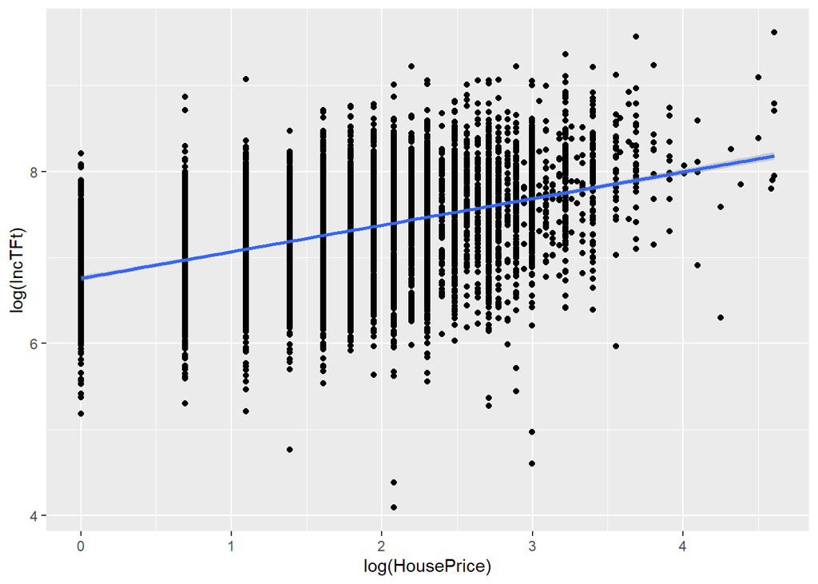

```r
# connection with both variables logarithmized
ggplot(hh_filtered, aes(x=log(HousePrice), y=log(IncTFt))) +
  geom_point() + geom_smooth(method = lm)
```

So, if we include the variable **HousePrice** in the model, we have to do it in a log-log way. This will give us a **mixed model** because it has both log-lin and log-log parts:

```r
mixed <- lm(log(IncTFt) ~ NrMems + HhEd + HhAge + I(HhAge^2) + log(HousePrice), data=hh_filtered)
summary(mixed)
```

```
##
## Call:
## lm(formula = log(IncTFt) ~ NrMems + HhEd + HhAge + I(HhAge^2) +
##     log(HousePrice), data = hh_filtered)
##
## Residuals:
##     Min      1Q  Median      3Q     Max
## -3.6561 -0.2435  0.0042  0.2493  1.7310
##
## Coefficients:
##                   Estimate Std. Error t value Pr(>|t|)
## (Intercept)      6.009e+00  5.252e-02 114.413  < 2e-16 ***
## NrMems           2.168e-01  3.779e-03  57.372  < 2e-16 ***
## HhEd             5.354e-02  1.755e-03  30.505  < 2e-16 ***
## HhAge            6.732e-03  2.018e-03   3.336 0.000854 ***
## I(HhAge^2)      -9.958e-05  1.917e-05  -5.195 2.11e-07 ***
## log(HousePrice)  1.739e-01  6.661e-03  26.108  < 2e-16 ***
## ---
## Signif. codes:  0 '***' 0.001 '**' 0.01 '*' 0.05 '.' 0.1 ' ' 1
##
## Residual standard error: 0.4022 on 7563 degrees of freedom
## Multiple R-squared:  0.5388, Adjusted R-squared:  0.5385
## F-statistic:  1767 on 5 and 7563 DF,  p-value: < 2.2e-16
```

So, for example, the coefficients of the model can be read like this:

- $e^{\beta_{HhEd}}=1.054999$: If the education of the head of household increases by 1 year, ceteris paribus, then the household income is expected to increase by 5.5%.
- $\beta_{\ln{HousePrice}}=0.17$: If the value of the home increases ceteris paribus by 1%, then the household income is expected to increase by 0.17%.

## 6. Lin-Log model

Let’s load a completely new file, BpFlats_New.xlsx. This spreadsheet is quite simple: it contains just 2 variables for 3000 households in Budapest:

- price: selling price of apartment (million Ft)
- area: area of apartment (m2)

```r
BP_Flats <- read_excel("BpFlats_New.xlsx")
str(BP_Flats)
```

```
## tibble [3,000 x 2] (S3: tbl_df/tbl/data.frame)
##  $ price: num [1:3000] 49.4 52.9 46.2 59.8 60.2 ...
##  $ area : num [1:3000] 42.8 49.5 39.8 64 49.5 ...
```

It is logical that here we will do a bivariate regression with $y=price$ and $x=area$, but let’s look at the distribution of our two variables as usually with a histogram:

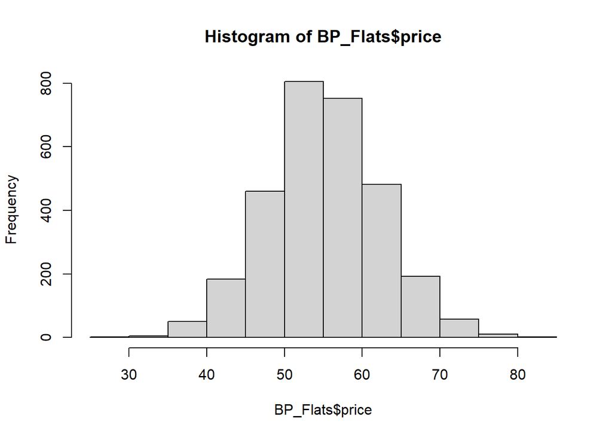

```r
hist(BP_Flats$price)
```

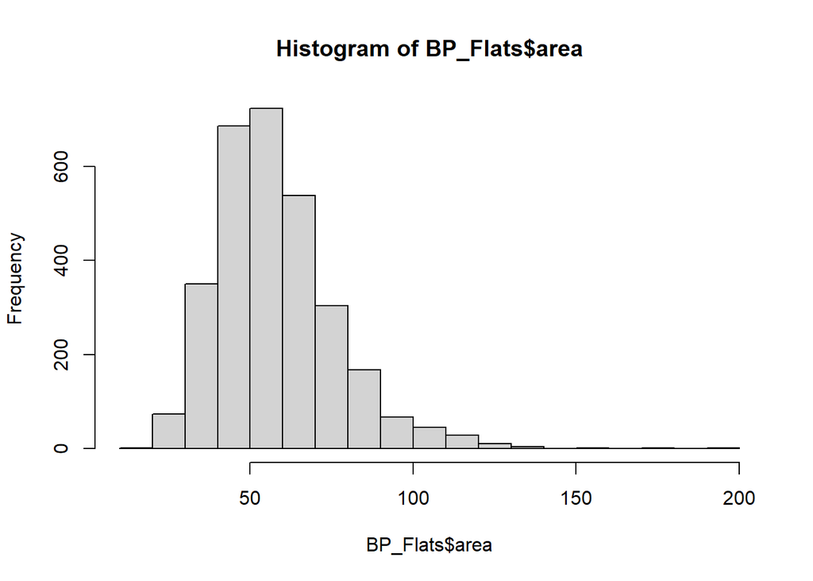

```r
hist(BP_Flats$area)
```

Now it is the house price, the outcome variable, that appears to be normally distributed, and the area that is more with a long right tail. Given these and our experience with log-log and log-lin models, we speculate that in this dataset the relationship between house price and area will be linear if area ($x$) is logarithmized but house price ($y$) is not. In other words, we are working with a **lin-log** model.

Let’s see the dot plot:

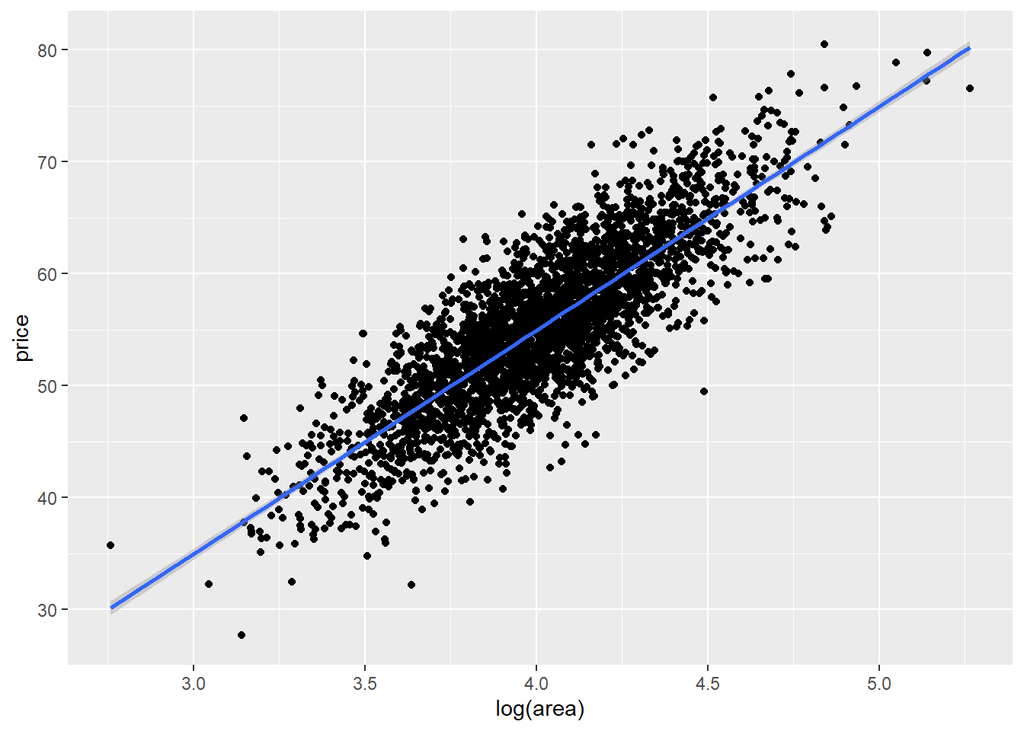

```r
# scatter plot with the logarithmized x variable
ggplot(BP_Flats, aes(x=log(area), y=price)) +
  geom_point() + geom_smooth(method = lm)
```

Our guess was correct, let’s examine the coefficients:

```r
linlog <- lm(price ~ log(area), data=BP_Flats)
summary(linlog)
```

```
##
## Call:
## lm(formula = price ~ log(area), data = BP_Flats)
##
## Residuals:
##      Min       1Q   Median       3Q      Max
## -15.4518  -2.6846  -0.0264   2.6520  13.3698
##
## Coefficients:
##             Estimate Std. Error t value Pr(>|t|)
## (Intercept) -24.9877     0.9725  -25.69   <2e-16 ***
## log(area)    19.9819     0.2417   82.66   <2e-16 ***
## ---
## Signif. codes:  0 '***' 0.001 '**' 0.01 '*' 0.05 '.' 0.1 ' ' 1
##
## Residual standard error: 3.994 on 2998 degrees of freedom
## Multiple R-squared:  0.695,  Adjusted R-squared:  0.6949
## F-statistic:  6832 on 1 and 2998 DF,  p-value: < 2.2e-16
```

In such a **lin-log model**, the slope of our explanatory variable should be interpreted as follows. $\beta_{area}=19.98$: i.e. +1% increase in area is expected to increase the price of the apartment by 0.1998 (19.98/100) million HUF.

## 7. Reciprocal Model

The last non-linear model specification we will look at is the reciprocal model. To do this, we will import the file IMR.csv, which contains 2 variables for 144 countries on Earth:

- IMR: Infant mortality rate (%)
- GDP: GDP per capita (dollars per capita)

```r
IMRData <- read.csv("IMR.csv")
str(IMRData)
```

```
## 'data.frame':    144 obs. of  2 variables:
##  $ IMR: num  68.1 13.2 3.2 3 55.8 65.7 62.2 32.1 9.7 5.6 ...
##  $ GDP: num  1933 8070 43930 46223 770 ...
```

Let’s examine the relationship between the variables **IMR** and **GDP** on a scatter plot by plotting the **non-linear trend line** that best fits the points:

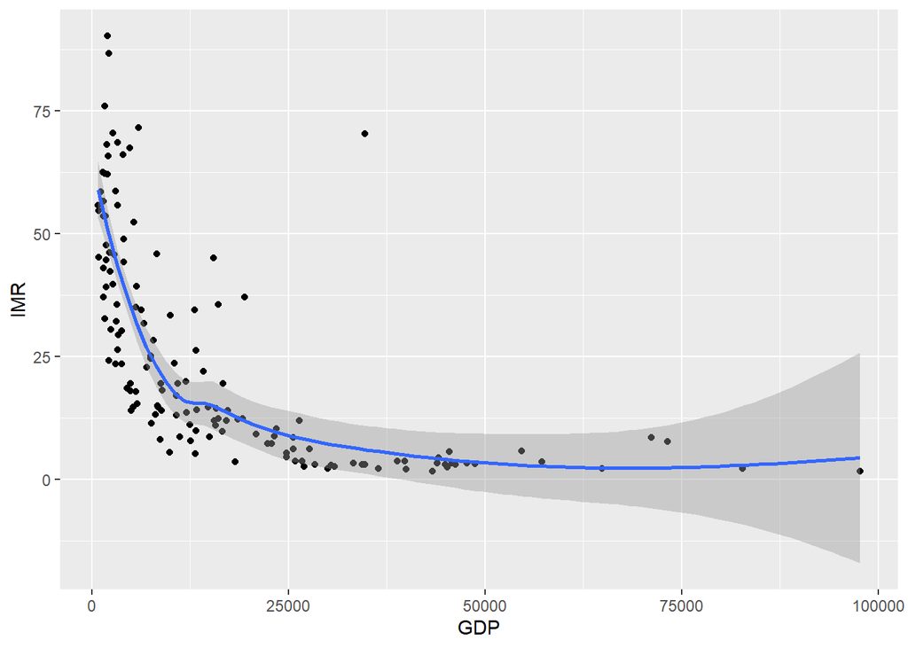

```r
ggplot(IMRData, aes(x=GDP, y=IMR)) +
  geom_point() + geom_smooth()
```

The shape that emerges could even be considered a *hyperbola*, i.e. a $1/x$ function! Let’s build our OLS model with this in mind:

```r
reciprocal <- lm(IMR ~ I(1/GDP), data=IMRData)
summary(reciprocal)
```

```
##
## Call:
## lm(formula = IMR ~ I(1/GDP), data = IMRData)
##
## Residuals:
##     Min      1Q  Median      3Q     Max
## -41.716 -10.270  -5.135   4.785  56.177
##
## Coefficients:
##              Estimate Std. Error t value Pr(>|t|)
## (Intercept)    12.362      1.719   7.194 3.33e-11 ***
## I(1/GDP)    61171.207   5389.067  11.351  < 2e-16 ***
## ---
## Signif. codes:  0 '***' 0.001 '**' 0.01 '*' 0.05 '.' 0.1 ' ' 1
##
## Residual standard error: 15.93 on 142 degrees of freedom
## Multiple R-squared:  0.4757, Adjusted R-squared:  0.472
## F-statistic: 128.8 on 1 and 142 DF,  p-value: < 2.2e-16
```

So, according to the model equation, $Estimated IMR=12.36+\frac{61171.21}{GDP}$.

What does $\beta_{1/GDP}=61171.21$ mean here? Well, practically nothing. :)

Here, the marginal effect and the elasticity must always be calculated with a separate partial derivative and both will depend on the initial level or value of the explanatory variable and/or the outcome variables level or value.

Let’s see the **marginal effect** in the reciprocal model!

$$\frac{\partial \hat{y}}{\partial x}=\frac{\partial\left(\beta_0+\frac{\beta_1}{x}\right)}{\partial x}=\beta_1 \times -x^{-2} = -\frac{\beta_1}{x^2}$$

So in our particular case, the marginal effect is $-\frac{61171.21}{GDP^2}$. For example, in Hungary $GDP=16476$. So, here the marginal effect is $-\frac{61171.21}{16476^2}=-0.00023$.So in Hungary, if GDP per capita would increase by 1 dollar/capita compared to 16476 dollars/capita, the infant mortality rate would decrease by 0.00023 percentage points. That’s not much, but it changes if we look at Yemen with its GDP of 645/person:
$$-\frac{61171.21}{645^2}=-0.15$$

And let’s look at **elasticity**. As calculated earlier, the elasticity is the marginal effect multiplied by $\frac{x}{\hat{y}}$. Here, in the reciprocal model, this means:
$$El=-\frac{\beta_1}{x^2} \times \frac{x}{\hat{y}} = -\frac{\beta_1}{x \times \hat{y}}$$

Let’s stick with the Yemen example: $\hat{y}=12.36+61171.21/645=107.2$. So the elasticity: $-\frac{61171.21}{645 \times 107.2}=-0.884$

So, if Yemen’s GDP per capita increases by 1% compared to **$645 per capita**, the infant mortality rate is expected to decrease by 0.88%.